# Assignment 5

Kyle Walker

9/30/2019

### Assignment 5. Data Visualization with ggplot2

#### Submission Instruction. You will need to submit on Blackboard, in the Assignment section, a link to your assignment on your Github Webpage. Following this to create a github webpage and posted a link to your assignment. This assignment works with the c2015 dataset.

```r
library(tidyverse)
library(readxl)
library(stringr)
c2015 <- read_excel("C:/Users/student/Documents/Senior Year/MATH 421/Assignment 2/c2015.xlsx")
```

#### 1. Clean the data for easy graphing. Do the follows to clean and reduce the size of the data.

##### Remove all observations that have a cell being either (1) NA, (2)‘Unknown’, (3)‘Not Rep’, or (4)‘Not Reported’

##### Remove all observations that have a cell containing either (1)‘Unknown’, (2)‘Not Rep’, or (3)‘Not Reported’. For instance, observations with DRINKING variable being Unknown (Police Reported) will be removed.

##### Fix TRAV_SP and AGE (following previous assignments) so that they are both numerics.

##### Filter so that there are only drivers in the data

```r
#Fixing Sex
c2015$SEX[is.na(c2015$SEX)]<- "Female"
#Fixing Age
c2015$AGE[c2015$AGE == 'Less than 1'] <- "0"
c2015$AGE <- as.numeric(c2015$AGE)
c2015$AGE[is.na(c2015$AGE)] <- mean(c2015$AGE)
#Fixing Trav_Sp
c2015$TRAV_SP <- str_replace(c2015$TRAV_SP, " MPH", "")
c2015$TRAV_SP <- str_replace(c2015$TRAV_SP, "Not Rep", "")
c2015$TRAV_SP <- str_replace(c2015$TRAV_SP, "Unknown", "")
c2015$TRAV_SP <- as.numeric(c2015$TRAV_SP)
c2015 = c2015[!(is.na(c2015$TRAV_SP)),]
#Getting rid of missing data
c2015 = c2015 %>%
  filter_all(~!is.na(.))
c2015 = c2015 %>%
  filter_all(~!(.=="Unknown"))
c2015 = c2015 %>%
  filter_all(~!(.=="Not Rep"))
c2015 = c2015 %>%
  filter_all(~!(.=="Not Reported"))
c2015 = c2015 %>%
  filter_all(~!(.==str_detect(.,"Not Rep")))
c2015 = c2015 %>%
  filter_all(~!(.==str_detect(.,"Unknown")))
c2015 = c2015 %>%
  filter(SEAT_POS == 'Front Seat, Left Side')
```

#### 2. Use geom_point to plot AGE and TRAV_SP coloring by SEX.

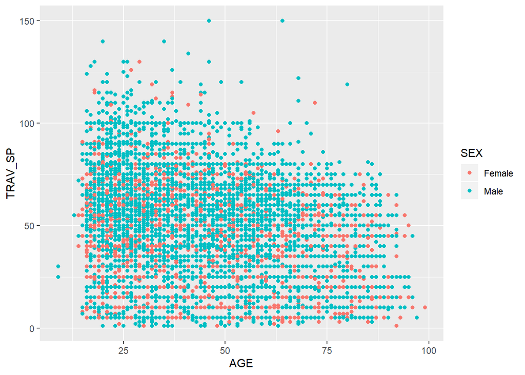

```r
ggplot(c2015, aes(x=AGE, y=TRAV_SP, col=SEX)) + geom_point()
```

#### 3. There is overplotting in 2. Overplotting is when many points are duplicated on the graph. Use geom_jitter instead of geom_point for 2. to avoid overplotting.

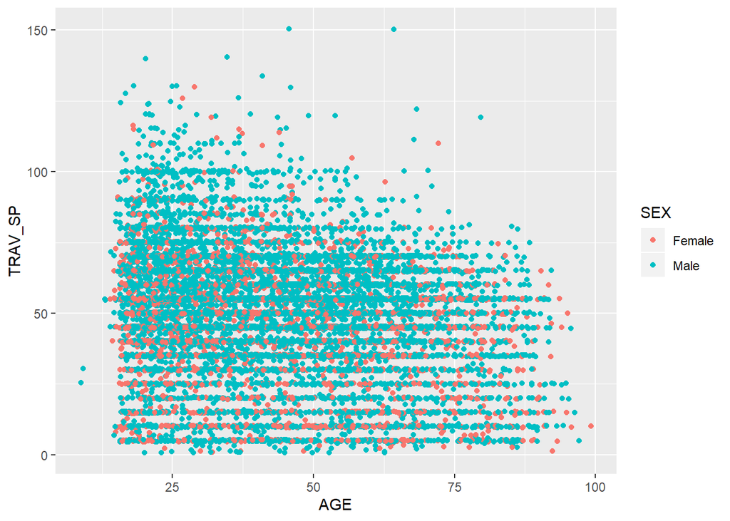

```r
ggplot(c2015, aes(x=AGE, y=TRAV_SP, col=SEX)) + geom_jitter()
```

#### 4. Plot histograms of AGE, TRAV_SP with bins = 50.

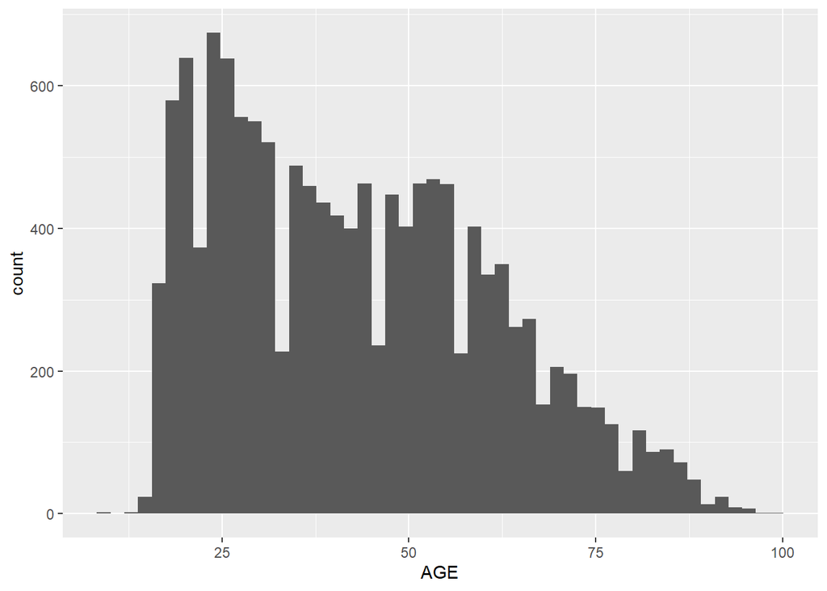

```r
ggplot(c2015, aes(x=AGE)) + geom_histogram(bins=50)
```

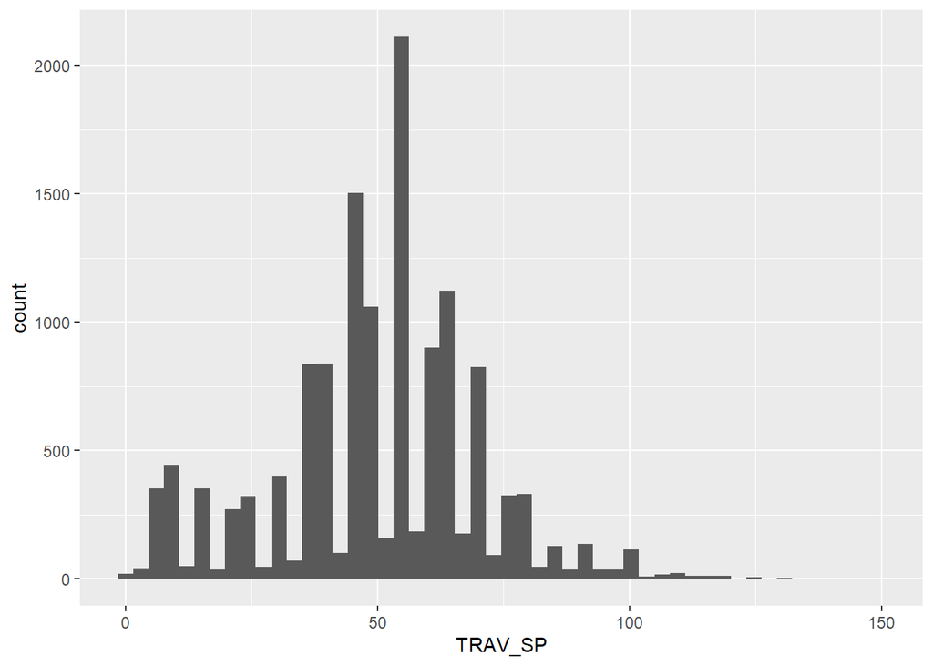

```r
ggplot(c2015, aes(x=TRAV_SP)) + geom_histogram(bins=50)
```

#### 5. Plot a histogram of AGE coloring (fill) by SEX.

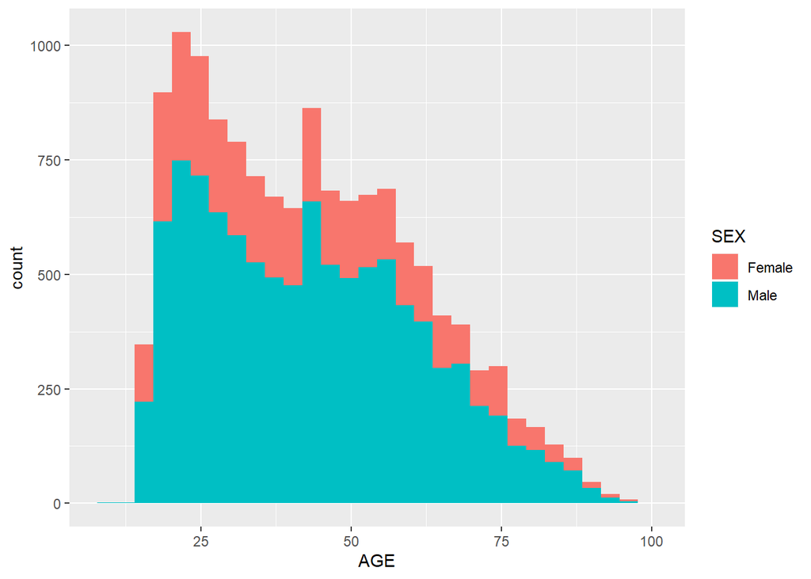

```r
ggplot(c2015, aes(x=AGE, fill=SEX)) + geom_histogram()
```

#### 6. Using geom_density to plot estimated densities of AGE colored by SEX.

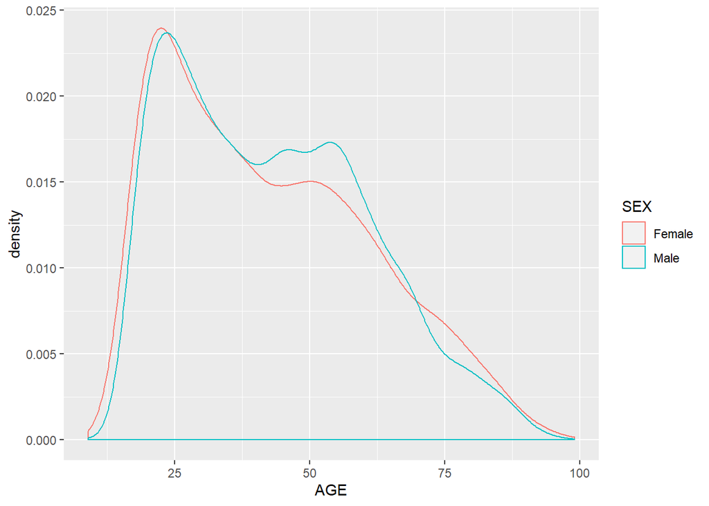

```r
ggplot(c2015, aes(AGE, col=SEX)) + geom_density()
```

#### 7. Plot estimated densities of TRAV_SP colored by INJ_SEV.

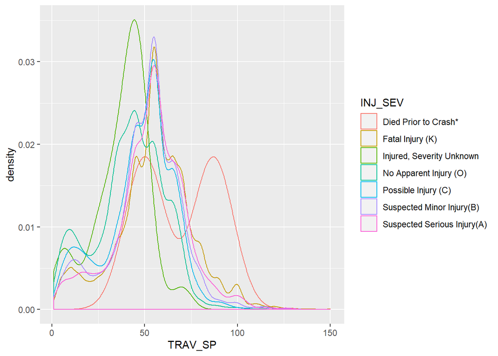

```r
ggplot(c2015, aes(TRAV_SP, col = INJ_SEV)) + geom_density()
```

#### 8. Plot estimated densities of TRAV_SP seperated (colored) by weekdays and weekends.

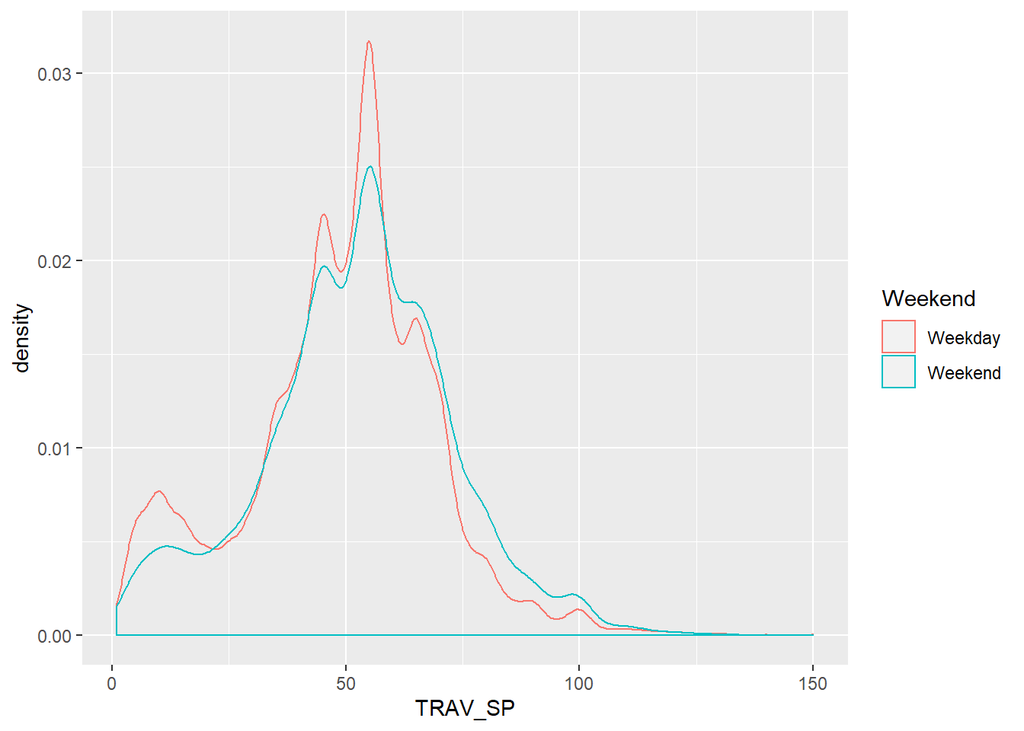

```r
c2015 <- c2015 %>%
  mutate(Weekend = case_when(
    DAY_WEEK %in% c("Saturday", "Sunday") ~ "Weekend",
    TRUE ~ "Weekday")
  )
ggplot(c2015, aes(TRAV_SP, col= Weekend)) + geom_density()
```

#### 9. Implement geom_bar on MONTH. Implement geom_bar on MONTH filled by SEX

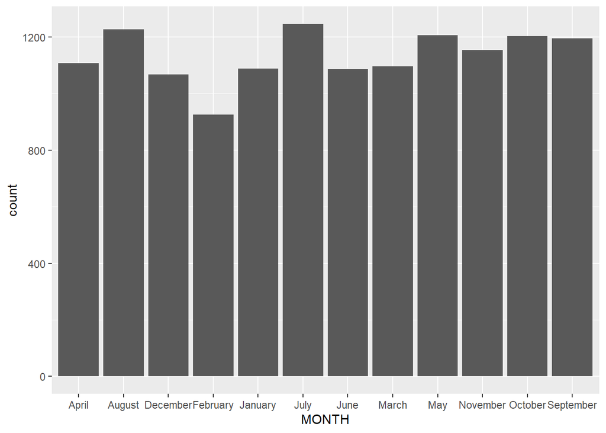

```r
ggplot(c2015, aes(x=MONTH)) + geom_bar()
```

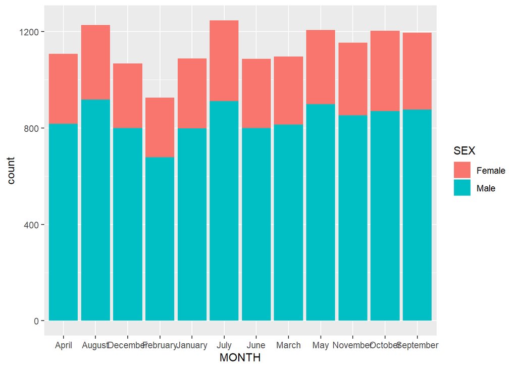

```r
ggplot(c2015, aes(x=MONTH, fill=SEX)) + geom_bar()
```

#### 10. Implement geom_bar on MONTH and SEX with position=‘dodge’

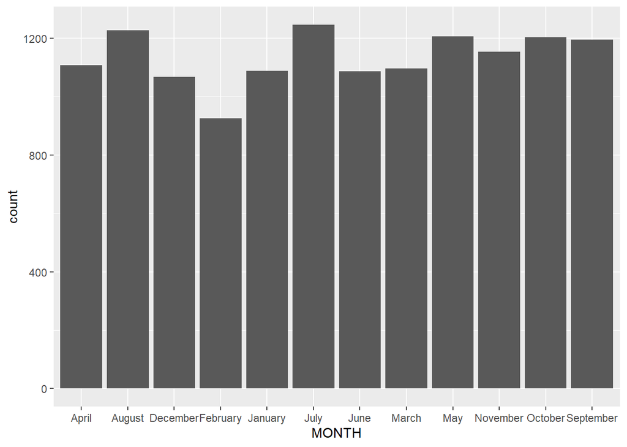

```r
ggplot(c2015, aes(x=MONTH)) + geom_bar(position = "dodge")
```

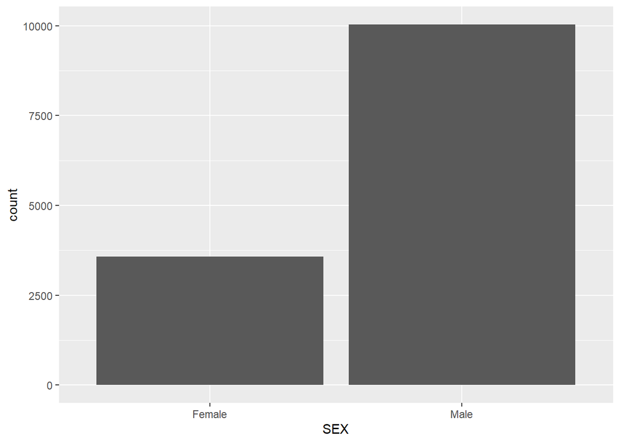

```r
ggplot(c2015, aes(x=SEX)) + geom_bar(position = "dodge")
```

#### 11. Plot a bar chart of average speeds in months using geom_col

```r
avgMSpd <- c2015 %>%
  group_by(MONTH) %>%
   summarize(AvgSpd = mean(TRAV_SP))
avgMSpd
```

```
## # A tibble: 12 x 2
##    MONTH     AvgSpd
##    <chr>      <dbl>
##  1 April       49.7
##  2 August      50.9
##  3 December    50.8
##  4 February    48.3
##  5 January     49.5
##  6 July        50.1
##  7 June        50.0
##  8 March       49.4
##  9 May         49.6
## 10 November    50.1
## 11 October     50.7
## 12 September   49.6
```

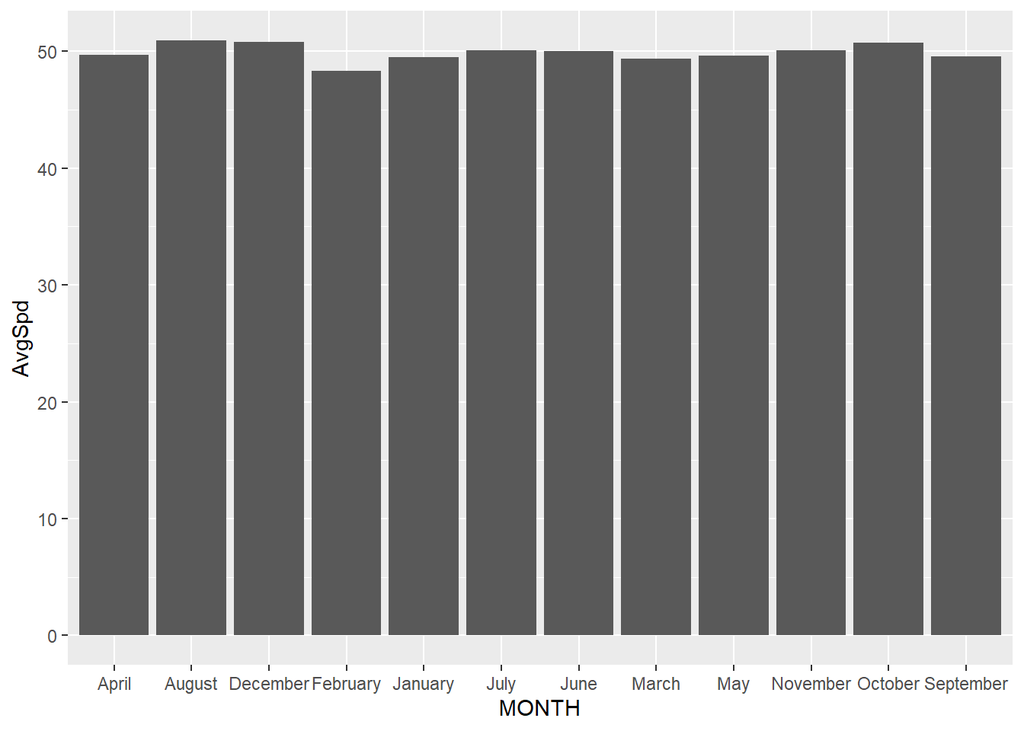

```r
ggplot(avgMSpd, aes(x=MONTH, y=AvgSpd)) + geom_col()
```

#### 12. Plot a bar chart of average speeds in months using geom_bar

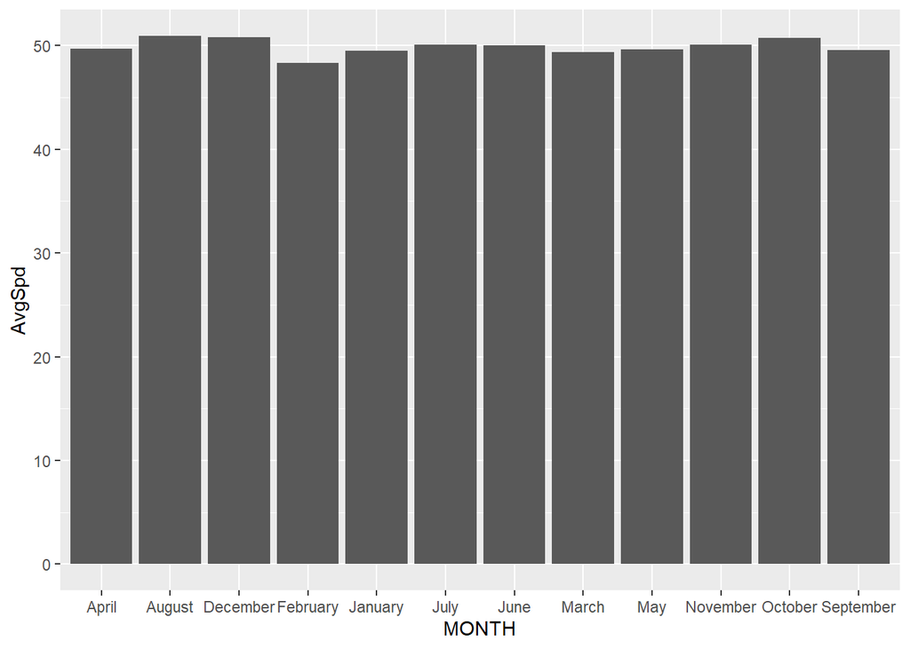

```r
ggplot(avgMSpd, aes(x=MONTH, y=AvgSpd)) + geom_bar(stat = 'identity')
```

#### 13. Plot a bar chart of average speeds in months filled by SEX

```r
SpdSex <- c2015 %>%
  group_by(MONTH, SEX) %>%
    summarize(AvgSpd = mean(TRAV_SP))
SpdSex
```

```
## # A tibble: 24 x 3
## # Groups:   MONTH [12]
##    MONTH    SEX    AvgSpd
##    <chr>    <chr>   <dbl>
##  1 April    Female   46.1
##  2 April    Male     51.0
##  3 August   Female   46.6
##  4 August   Male     52.4
##  5 December Female   47.6
##  6 December Male     51.9
##  7 February Female   45.7
##  8 February Male     49.3
##  9 January  Female   43.7
## 10 January  Male     51.6
## # ... with 14 more rows
```

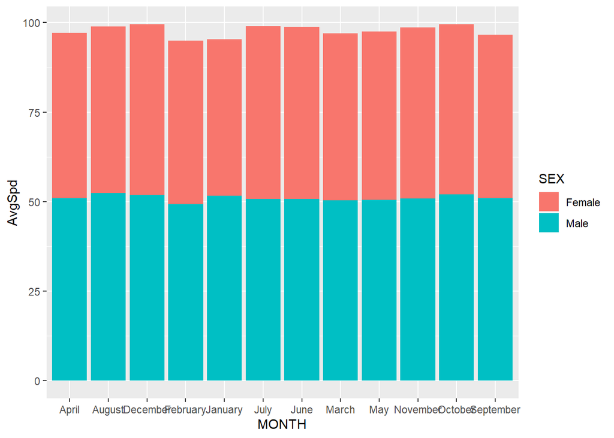

```r
ggplot(SpdSex, aes(x=MONTH, y=AvgSpd, fill=SEX)) + geom_bar(stat= "identity")
```

#### 14. Plot a bar chart of average speeds in months colored by INJ_SEV

```r
SpdSev <- c2015 %>%
  group_by(MONTH, INJ_SEV) %>%
    summarize(AvgSpd = mean(TRAV_SP))
SpdSev
```

```
## # A tibble: 72 x 3
## # Groups:   MONTH [12]
##    MONTH  INJ_SEV                     AvgSpd
##    <chr>  <chr>                        <dbl>
##  1 April  Died Prior to Crash*          87
##  2 April  Fatal Injury (K)              54.3
##  3 April  No Apparent Injury (O)        40.2
##  4 April  Possible Injury (C)           48.2
##  5 April  Suspected Minor Injury(B)     50.7
##  6 April  Suspected Serious Injury(A)   53.0
##  7 August Fatal Injury (K)              56.0
##  8 August Injured, Severity Unknown     48.7
##  9 August No Apparent Injury (O)        42.3
## 10 August Possible Injury (C)           46.2
## # ... with 62 more rows
```

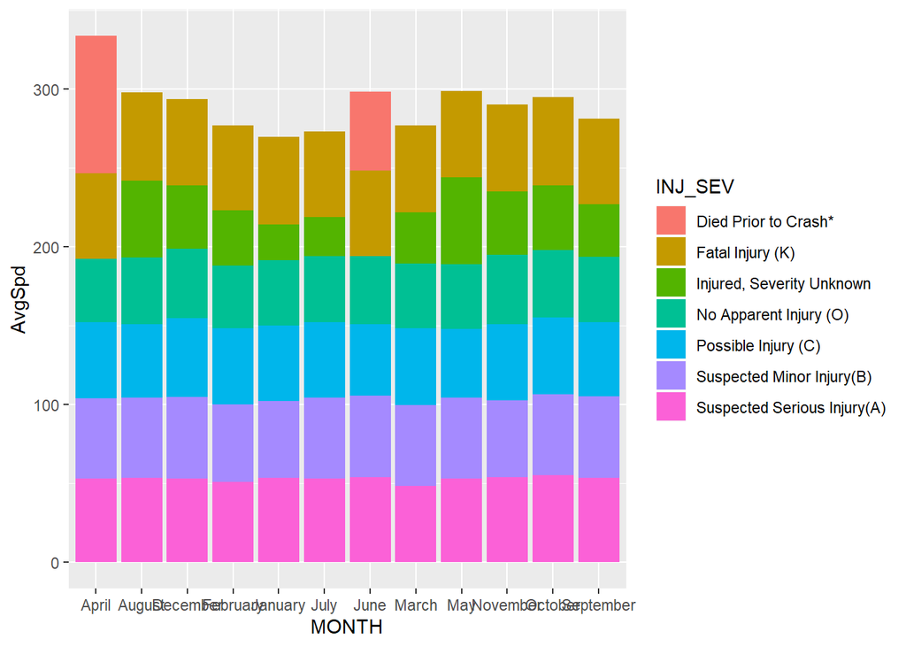

```r
ggplot(SpdSev, aes(x=MONTH, y=AvgSpd, fill=INJ_SEV)) + geom_bar(stat= "identity")
```

#### 15. Refer to this link to have a similar following plot:

##### Horizontal axis is for (monthly) average speed

##### The vertical axis is for months

##### Color by two colors: one for above overall average speed and the other for below the avarage speed

##### The speed on the horizontal axis is standardized

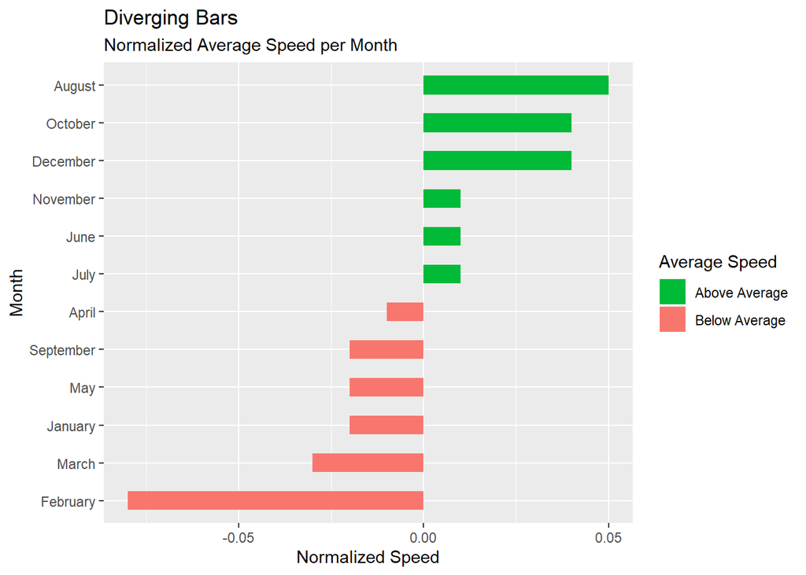

```r
cum_mean <- mean(c2015$TRAV_SP)
cum_sd <- sd(c2015$TRAV_SP)
gph15 <- c2015 %>%
  group_by(MONTH) %>%
     summarize(spd_z = round(((mean(TRAV_SP,na.rm=T)- cum_mean) / cum_sd),2)) %>%
       mutate(type = ifelse(spd_z > 0 , "above", "below")) %>%
         arrange(spd_z)

ggplot(gph15, aes(x=reorder(MONTH,spd_z), y=spd_z, label = spd_z)) +
  geom_bar(stat='identity', aes(fill = type, width=0.5)) +
    scale_fill_manual(name = "Average Speed",
                      labels = c("Above Average" , "Below Average"),
                      values = c("above" = "#00ba38", "below" = "#f8766d")) +
  labs(subtitle = "Normalized Average Speed per Month",
       title = "Diverging Bars",
       x= "Month",
       y= "Normalized Speed") +
  coord_flip()
```

#### 16. Refer to this link to have a similar following plot:

##### Horizontal Axis is for mean speed

##### Vertical Axis is for INJ_SEV

##### The numbers of speed are shown in points.

[figure not shown]

```r
gph16 <- c2015 %>%
  group_by(INJ_SEV, SEX) %>%
    summarize(spd= round(mean(TRAV_SP),2))

ggplot(gph16, aes(x=reorder(INJ_SEV,spd), y=spd, label = spd)) +
  geom_point(stat='identity', aes(col = SEX), size=9) +
    scale_color_manual(name = "Sex",
                      labels = c("Male" , "Female"),
                      values = c("Male" = "blue", "Female" = "red")) +
  geom_text(color="white", size=2) +
  labs(subtitle = "Average Speed per Month",
       title = "Diverging Dot Plot",
       x= "Injury Severity",
       y= "Mean Speed") +
  coord_flip()
```

#### 18. Refer to this link to have a similar following plot:

##### Horizontal Axis is for speed

##### The should be a invisible vertical line seperating the two sexes.

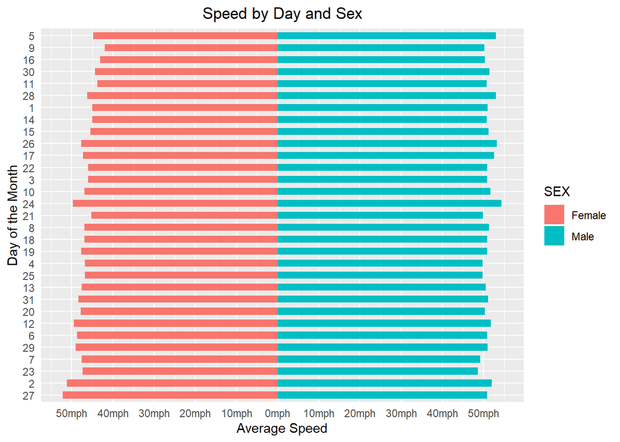

```r
brks <- seq(-60,60,10)
lbls <- paste0(as.character(c(seq(60,0,-10), seq(10,60,10))), "mph")


c2015 %>%
  group_by(DAY, SEX) %>%
    summarize(avg= round((mean(TRAV_SP, na.rm=T)),2)) %>%
      mutate(avg = ifelse(SEX == "Female",-avg, avg)) %>%
        ggplot(aes(x=reorder(DAY, avg), y= avg, fill= SEX)) +
        geom_bar(stat='identity', width=0.6) +
        scale_y_continuous(breaks = brks,
                           labels = lbls) +
        coord_flip() +
        labs(title= "Speed by Day and Sex",
             y = "Average Speed",
             x = "Day of the Month") +
        theme(plot.title = element_text(hjust= 0.5),
              axis.ticks = element_blank())
```

#### 18-20. Generate three other interesting graphs from the dataset.

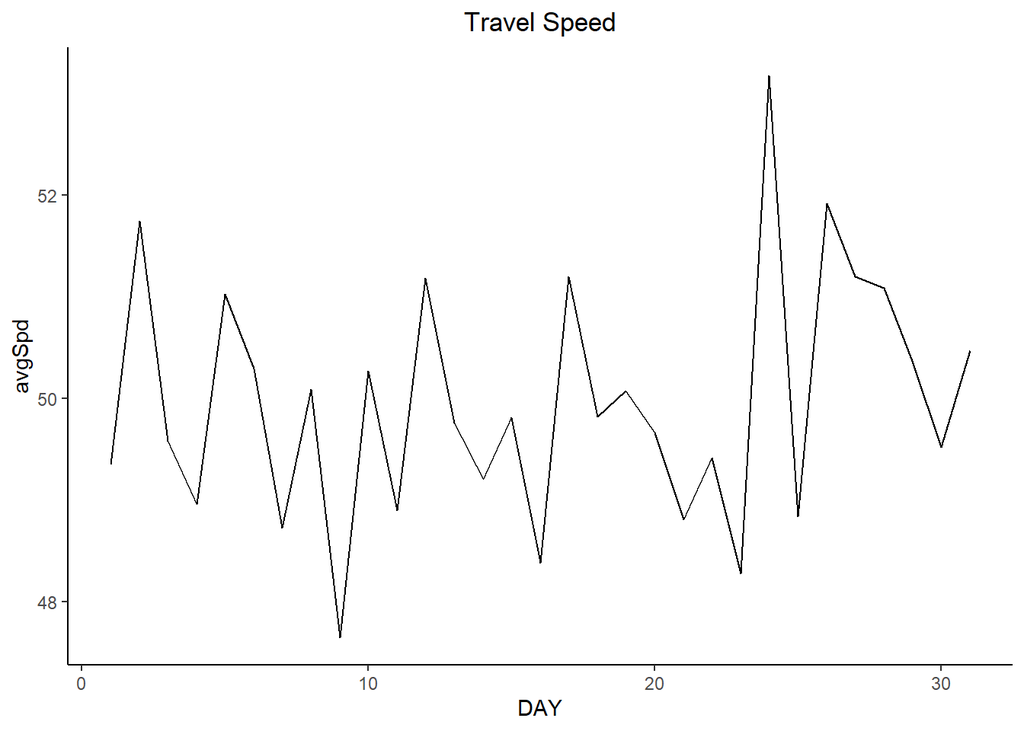

```r
library(ggfortify)
theme_set(theme_classic())

ts <- c2015 %>%
  group_by(DAY) %>%
    summarize(avgSpd = mean(TRAV_SP))

ggplot(ts, aes(x=DAY)) +
  geom_line(aes(y=avgSpd)) +
  labs(title= "Travel Speed") +
  theme(plot.title = element_text(hjust= 0.5))
```

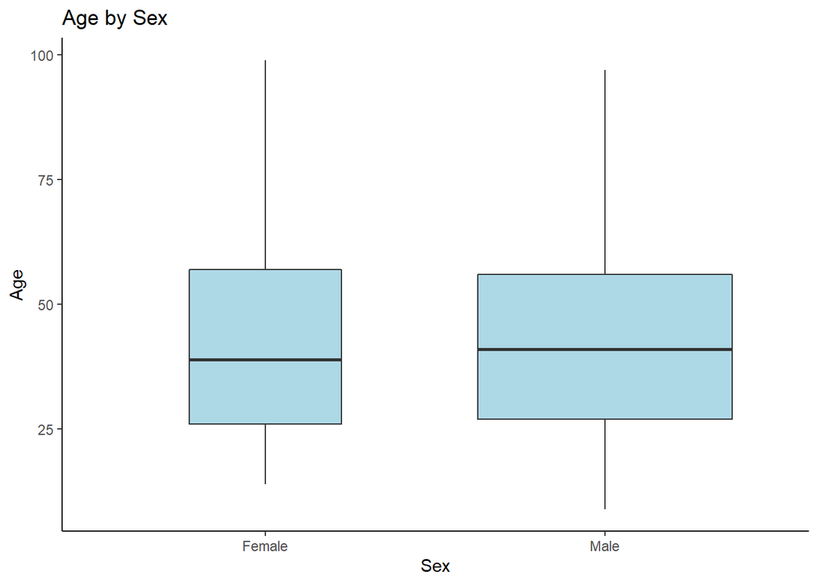

```r
ggplot(c2015, aes(SEX, AGE)) +
  geom_boxplot(varwidth = T, fill = "light blue") +
  labs(title = "Age by Sex",
       x = "Sex",
       y= "Age")
```

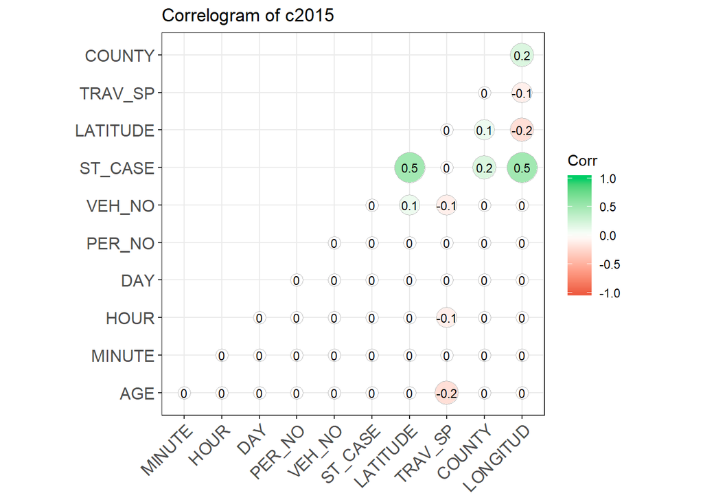

```r
library(ggcorrplot)

c2015_n <- c2015 %>%
  select_if(is.numeric) %>%
    select(-"YEAR")

corr <- round(cor(c2015_n),1)

ggcorrplot(corr, hc.order = T,
       type = "lower",
       lab = T,
       lab_size = 3,
       method = "circle",
       colors = c("tomato2", "white", "springgreen3"),
       title = "Correlogram of c2015",
       ggtheme = theme_bw)
```